# Verbal Aggression Data: Motivating Questions — Instructor Answer Key

# 10 Person Parameter Estimates: MLE vs. EAP Across Models

Person parameter estimation methods and model choice both affect the $\hat{\theta}$ values assigned to respondents. This section compares **Maximum Likelihood Estimation (MLE)** and **Expected A Posteriori (EAP)** estimation within the PCM, and then compares **EAP estimates across all four models**.

## 10.1 MLE vs. EAP Within the PCM

```r
# EAP estimates for all models
eap_pcm  <- fscores(pcm,  method = "EAP", full.scores = TRUE)[, 1]
eap_gpcm <- fscores(gpcm, method = "EAP", full.scores = TRUE)[, 1]
eap_rsm  <- fscores(rsm,  method = "EAP", full.scores = TRUE)[, 1]
eap_grm  <- fscores(grm,  method = "EAP", full.scores = TRUE)[, 1]

# MLE estimates for PCM (may be Inf/-Inf for perfect scores)
mle_pcm_raw <- fscores(pcm, method = "ML", full.scores = TRUE)[, 1]
finite_mle  <- is.finite(mle_pcm_raw)
cat(sprintf("MLE estimates: %d finite, %d non-finite (extreme scores)\n",
            sum(finite_mle), sum(!finite_mle)))
```

```
## MLE estimates: 310 finite, 6 non-finite (extreme scores)
```

```r
mle_pcm <- mle_pcm_raw  # keep for plotting; will filter where needed
```

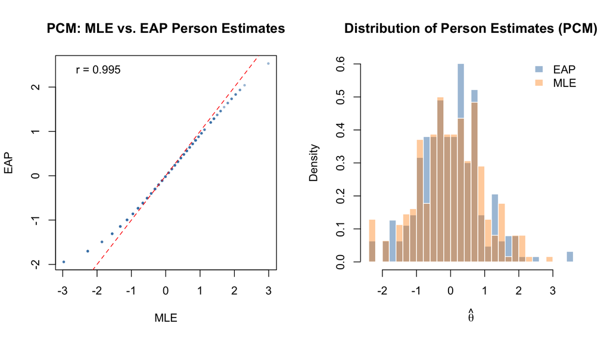

```r
par(mfrow = c(1, 2))

# Scatter: MLE vs EAP (finite MLE only)
plot(mle_pcm[finite_mle], eap_pcm[finite_mle],
     pch = 16, cex = 0.5, col = adjustcolor("steelblue", 0.5),
     xlab = "MLE", ylab = "EAP",
     main = "PCM: MLE vs. EAP Person Estimates")
abline(0, 1, col = "red", lty = 2)
r_mle_eap <- cor(mle_pcm[finite_mle], eap_pcm[finite_mle])
legend("topleft", legend = paste0("r = ", round(r_mle_eap, 3)), bty = "n")

# Histogram overlay
hist(eap_pcm, breaks = 30, col = adjustcolor("steelblue", 0.5),
     main = "Distribution of Person Estimates (PCM)",
     xlab = expression(hat(theta)), border = "white", freq = FALSE)
hist(mle_pcm[finite_mle], breaks = 30,
     col = adjustcolor("darkorange", 0.4), border = "white",
     add = TRUE, freq = FALSE)
legend("topright", legend = c("EAP", "MLE"),
       fill = c(adjustcolor("steelblue", 0.5), adjustcolor("darkorange", 0.4)),
       bty = "n", border = "white")
```

```r
par(mfrow = c(1, 1))
```

**Key findings — MLE vs. EAP:**

- MLE and EAP are **highly correlated** (r shown above) but differ systematically: EAP **shrinks estimates toward the mean** of the prior distribution (a standard normal by default in mirt). This means EAP estimates have a smaller range than MLE estimates.
- MLE **cannot estimate** $\theta$ for respondents with all-zero or all-maximum response patterns (scores of 0 or 48), because the likelihood is monotone and has no finite maximum. EAP handles these cases gracefully by pulling extreme respondents back toward the prior mean.
- For practical measurement decisions (e.g., reporting individual scores), EAP is generally preferred because it is finite and has lower mean squared error. MLE may be preferred when the researcher wants to avoid the shrinkage introduced by the prior.